# Raster Images

Carole Voulgaris

10/12/2020

## Load libaries

These are the libraries I’m using today:

```r
library(raster)
library(tidyverse)
library(RStoolbox)
library(ggthemes)
library(ggspatial)
library(osmdata)
```

## Load digital layer

First, I’ll download street features from Open Street Map. You might choose to use other spatial data describing some other feature, perhaps from a municipal Open Data portal.

```r
cambridge_street_features <- opq(bbox = 'Cambridge MA USA') %>%
  add_osm_feature(key = 'highway') %>%
  osmdata_sf()

cambridge_streets <- cambridge_street_features$osm_lines
```

## Load georeferenced image

Now I’ll load the georeferenced image I created in ArcMap, ArcGIS Pro, or QGIS, as shown in the video tutorials for this week. I can use the function `ggRGB` to plot the image. The r, g, and b arguments tell R which of the three image layers represent red, green, and blue, respectively.

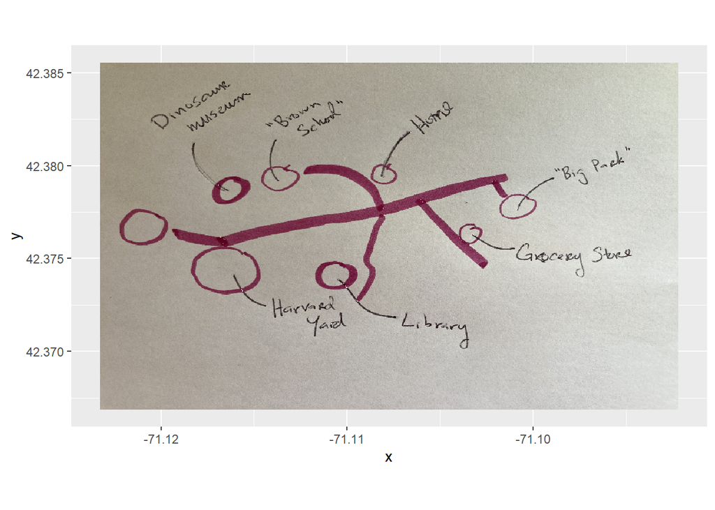

```r
nhood_image <- stack("hand-drawn-map_georef.tif")

ggRGB(nhood_image, r = 1, g = 2, b = 3)
```

## Plot georeferenced image with downloaded vector data

For your assignment, you’ll need to plot the georeferenced image on the same map with a layer of digital data. I can still use `ggRGB()` for this, but I need to set the argument `ggLayer = TRUE` to indicate that I’m adding the layer to a ggplot object.

I’ll draw the streets layer on top of the image, but I’ll make it mostly transparent (`alpha = 0.2`) so that you can still read the image under it.

I’ll use `coord_sf()` to “zoom in” on the part of the map where the image is.

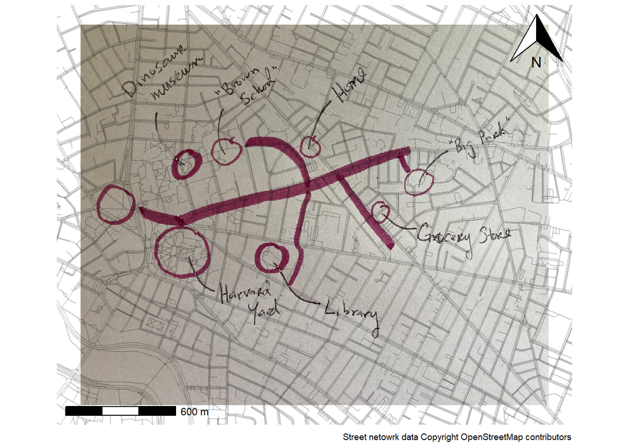

```r
ggplot(cambridge_streets) +
  ggRGB(nhood_image,
        r = 1, g = 2, b = 3, ggLayer = TRUE) +
  geom_sf(alpha = 0.2) +
  coord_sf(xlim = c(nhood_image@extent@xmin, nhood_image@extent@xmax),
           ylim = c(nhood_image@extent@ymin, nhood_image@extent@ymax)) +
  theme_map() +
  annotation_scale() +
  annotation_north_arrow(location = "tr") +
  labs(caption = "Street netowrk data Copyright OpenStreetMap contributors")
```

In your assignment, I’d love to see some commentary on what you’ve chosen to show and/or emphasize in your hand-drawn map and how the message of your map might be different from what you could have created using outside data sources alone.